# Some useful libraries

[Fanny Ducel](https://fannyducel.github.io/) (CC BY-NC-SA) -- 2024

Before we start:

- If someone has "exam accomodations" ("tiers temps", "aménagements"), please send me an email or let me know somehow so that I can prepare what you need
- Let's go back on Wooclap to address some notions from last week.

This notebook corresponds to your seventh lecture and covers (clickable sources):

- [Numpy](https://www.w3schools.com/python/numpy/default.asp)
- [Pandas](https://www.w3schools.com/python/pandas/default.asp)
- [Spacy](https://spacy.io/)
- [tqdm](https://tqdm.github.io/)
- [matplotlib](https://www.w3schools.com/python/matplotlib_getting_started.asp)

Unlike last week, these libraries are not pre-installed in your environment, so you may need to install them yourself:

`pip install pandas` in your terminal, or `!pip install pandas` directly in a notebook

You'll see that some of these libraries are partially coded in C or C++. That makes them much more efficient and faster than Python.

[figure not shown]

## Numpy

NumPy (Numerical Python) is a library used to work on arrays, in particular in data science.

It is much more efficient than the Python lists and **50 times faster**, as it is partially coded in C and C++. It also takes less space in memory.

```python
import numpy as np

arr = np.array([1, 2, 3, 4, 5])

print(arr, type(arr))
```

```
[1 2 3 4 5] <class 'numpy.ndarray'>
```

```python
# You can create multi-dimensional or 0-D arrays:

arr_0d = np.array(84)
arr_1d = np.array([1, 2, 3, 4, 5])
arr_2d = np.array([[4, 1, 3], [6, 2, 3]])
arr_3d = np.array([[[1, 2, 3], [4, 5, 6]], [[1, 2, 3], [4, 5, 6]]])
arr_5d = np.array([1, 2, 3, 4], ndmin=5)

print(arr_2d)

# Check the number of dimensions
print(arr_2d.ndim)

# Check the shape of the array
print(arr_2d.shape)
```

```
[[4 1 3]
 [6 2 3]]
2
(2, 3)
```

```python
# Like in lists, you can access array elements with indexes:
#print(arr_1d[2])
#print(arr_2d[1,1])

# You can also use slicing
#print(arr_1d[1:3])

# And for loops!
# TODO: how to go through an array with a for loop?
for row in arr_2d:
    for number in row:
        print(number)
```

```
4
1
3
6
2
3
```

```python
# You can also search array
search = np.where(arr_1d == 4)
print(search)

print(np.sort(arr_2d))
```

[output not shown]

## Pandas

A library to analyze, clean, explore, manipulate data easily. Built on top of NumPy. Very useful for data science.

```python
import pandas as pd

# You can convert a dict to a Dataframe

fruits = {
    "labels" : ["apple", "pineapple", "mango", "banana"],
    "prices" : [0.1, 0.8, 0.7, 0.2]
}

df_fruits = pd.DataFrame(fruits)

#df_fruits
#print(df_fruits.info())
print(df_fruits.loc[0])
```

```
labels    apple
prices      0.1
Name: 0, dtype: object
```

```python
# Read and clean a CSV file
# Random file from https://www.data.gouv.fr/fr/datasets/effectifs-deleves-par-niveau-sexe-langues-vivantes-1-et-2-les-plus-frequentes-par-college-date-dobservation-au-debut-du-mois-doctobre-chaque-annee/

# df = pd.read_csv("fr-en-college-effectifs-niveau-sexe-lv.csv")
df = pd.read_csv("fr-en-college-effectifs-niveau-sexe-lv.csv", sep=";")

# Let's have a first look at it to see what it is about
#print(df.info())
#df
```

```python
# Let's clean it up!
df = df.dropna()
# or: df.fillna("Undetermined")
df = df.drop_duplicates()

# To check if a cell is "na"
#print(df['code_region'].isna())

# To check if a cell is NOT "na"
#print(df['code_region'].notna())
```

[output not shown]

```python
# Manipulate the data
interesting_col = "nombre_de_3emes_lv1_anglais"

print("Mean",df[interesting_col].mean())
print("Median",df[interesting_col].median())
print("Min",df[interesting_col].min())
print("Max",df[interesting_col].max())
print("Correlation",df[interesting_col].corr(df["code_region"]))

print(df.sort_values(by=interesting_col))
```

```
Mean 95.2630670788698
Median 95.0
Min 0
Max 505
Correlation 0.06624079122832621
       num_ligne  rentree_scolaire  code_region     region_academique  \
30192      15279              2020           16             OCCITANIE
8037       40104              2023           16             OCCITANIE
2189       20812              2021           10         ILE-DE-FRANCE
13974      27423              2022            6             GRAND EST
22178      14822              2020           15    NOUVELLE-AQUITAINE
...          ...               ...          ...                   ...
6230         894              2019            1  AUVERGNE-RHONE-ALPES
5760       38664              2023           13               MAYOTTE
4940       34282              2023            1  AUVERGNE-RHONE-ALPES
```

[output cut: 82 more lines]

```python
# Create filters
filter_year = df[df['rentree_scolaire'] < 2020]
#print(filter_year)

filter_academie = df[df['academie'] == "NANCY-METZ"]
#filter_academie

filter_german = df[df['nombre_de_3emes_lv1_allemand'] > df['nombre_de_3emes_lv1_anglais']]
# filter_german

# Combine conditions (notice the syntax with brackets and '&' or '|')
filter_nancygerman = df[(df['academie'] == "NANCY-METZ") | (df['nombre_de_3emes_lv1_allemand'] > df['nombre_de_3emes_lv1_anglais'])]
#filter_nancygerman
```

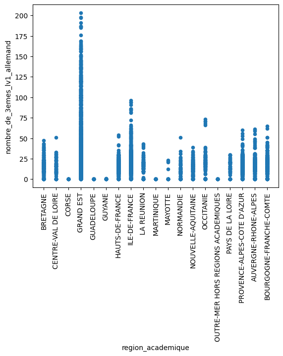

```python
# Visualize
import matplotlib.pyplot as plt
df.plot(kind = 'scatter', x = 'region_academique', y = 'nombre_de_3emes_lv1_allemand')

plt.xticks(rotation=90)
plt.show()
```

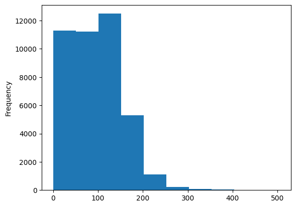

```python
df[interesting_col].plot(kind='hist')
```

## Spacy

For NLP: tokenization, POS tagging, dependency parsing, lemmatization, sentence boundary detection, NER, entity linking, similarity, text classification, rule-based matching, training, ...

Using trained models and pipelines for many languages. Some languages have transformer-based models (https://spacy.io/models):

`python -m spacy download en_core_web_sm` (or with a "!" in front if in a notebook)

*Note (NLP students) : For French, models are partially based on UD_French-Sequoia, a project featuring Bruno Guillaume!*

```python
import spacy

nlp = spacy.load("en_core_web_sm")
# From Wikipedia
pythonidae = nlp("The Pythonidae, commonly known as pythons, are a family of over 40 nonvenomous snakes found in Africa, Asia, and Australia.")

print("TEXT, LEMMA, POS, TAG, DEP")
for token in pythonidae:
    print(token.text, token.lemma_, token.pos_, token.tag_, token.dep_)
```

```
TEXT, LEMMA, POS, TAG, DEP
The the DET DT det
Pythonidae Pythonidae PROPN NNP nsubj
, , PUNCT , punct
commonly commonly ADV RB advmod
known know VERB VBN acl
as as ADP IN prep
pythons python NOUN NNS pobj
, , PUNCT , punct
are be AUX VBP ROOT
a a DET DT det
family family NOUN NN attr
of of ADP IN prep
over over ADP IN quantmod
40 40 NUM CD nummod
nonvenomous nonvenomous ADJ JJ amod
snakes snake NOUN NNS pobj
found find VERB VBN acl
in in ADP IN prep
Africa Africa PROPN NNP pobj
, , PUNCT , punct
Asia Asia PROPN NNP conj
, , PUNCT , punct
and and CCONJ CC cc
Australia Australia PROPN NNP conj
. . PUNCT . punct
```

```python
from spacy import displacy

displacy.render(pythonidae, style="dep")
```

[figure not shown]

```python
for ent in pythonidae.ents:
    print(ent.text, ent.start_char, ent.end_char, ent.label_)
```

```
over 40 59 66 CARDINAL
Africa 95 101 LOC
Asia 103 107 LOC
Australia 113 122 GPE
```

```python
displacy.render(pythonidae, style="ent")
```

The Pythonidae, commonly known as pythons, are a family of over 40 CARDINAL nonvenomous snakes found in Africa LOC , Asia LOC , and Australia GPE .

```python
python = nlp("Python is a programming language that we are currently learning.")
master = nlp("I am a master's students  , I study computer science and programming among other things")

# Similarity of two documents
print(python.similarity(master))

print(python.similarity(pythonidae))

print(pythonidae.similarity(master))
```

```
0.40341952443122864
0.22934463620185852
0.424297958612442
```

🥳 **YOUR TURN**: Compute the similarity between the 3rd word from the text `python`, and the 9th word from `master`

```python
# CODE ME
python_ = "Pythons are snakes..."
p3 = python[3]
m9 = master[9]
print(p3, m9)
print(p3.similarity(m9))
```

```
programming computer
0.5470353960990906
```

## tqdm

A library to display progress bars for Python loops

```python
from tqdm import tqdm
import time

# The syntax is the following: for word in tqdm(word_list)
```

```python
for i in tqdm(range(1,21)):
    print(i)
    time.sleep(1)
```

```
1
```

```
2
```

```
3
```

```
4
```

```
5
```

```
6
```

```
7
```

```
8
```

```
9
```

```
10
```

```
11
```

```
12
```

```
13
```

```
14
```

```
15
```

```
16
```

```
17
```

```
18
```

```
19
```

```
20
```

## matplotlib

To plot graphs, useful for visualization.

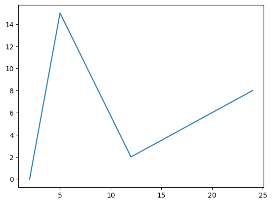

```python
import matplotlib.pyplot as plt
import numpy as np

# Let's make a basic, random plot
xpoints = np.array([2, 5, 12, 24])
ypoints = np.array([0, 15, 2, 8])

plt.plot(xpoints, ypoints)
plt.savefig("my_plot.pdf")
plt.show()
```

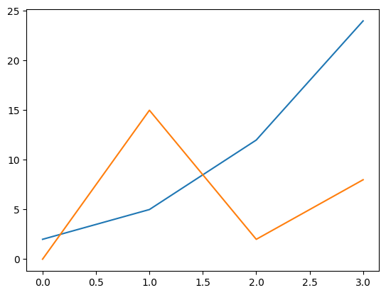

```python
# Notice the syntax difference for one or multiple lines
plt.plot(xpoints)
plt.plot(ypoints)
plt.show()
```

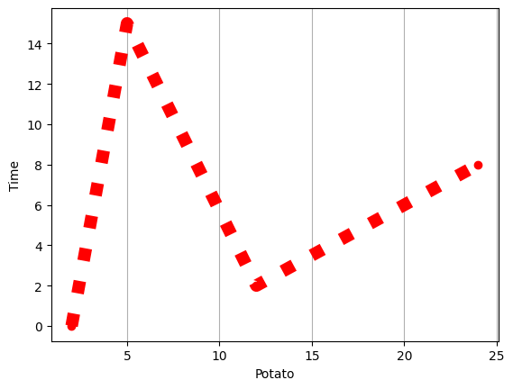

```python
# Let's make it prettier/more interesting (endless possibilities/options!)
#plt.plot(xpoints, ypoints, marker="o")
#plt.plot(xpoints, ypoints, linestyle = 'dotted')
plt.plot(xpoints, ypoints, color= 'r', linewidth = '10', linestyle="dotted", marker="o")

plt.xlabel("Potato")
plt.ylabel("Time")
#plt.grid()
plt.grid(axis='x')
plt.show()
```

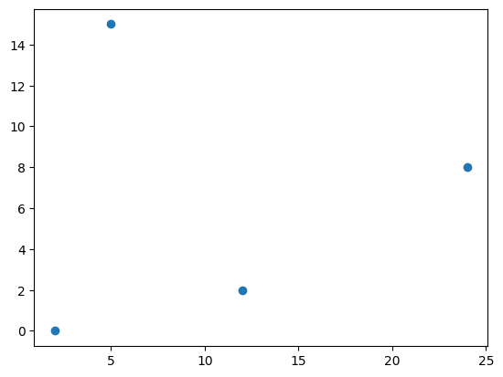

```python
# More plot types!
plt.scatter(xpoints, ypoints)
plt.show()
```

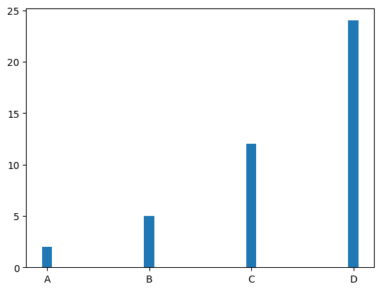

```python
plt.bar(["A", "B", "C", "D"], xpoints, width=0.1)
plt.show()
```

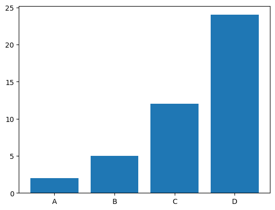

```python
plt.bar(["A", "B", "C", "D"], xpoints), #height=0.1
plt.show()
```

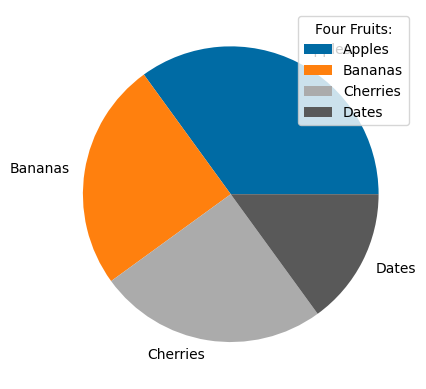

```python
# Note: be careful when plotting, try to make it color-blind friendly for greater inclusivity!
plt.style.use('tableau-colorblind10')

y = np.array([35, 25, 25, 15])
mylabels = ["Apples", "Bananas", "Cherries", "Dates"]

plt.pie(y, labels = mylabels)
plt.legend(title = "Four Fruits:", loc="upper right")
plt.show()
```

🥳 **YOUR TURN**: Create a dictionary with any data you'd like inside and make a plot out of it (any kind of plot you'd like)!

That's all for today! Any questions?